# LASI21

## W3: Introduction to Machine Learning for Learning Analytics

### Instructors: Alfred Essa, Lalitha Agnihotri

# Day 1: Agenda

- **Preliminaries**
  - Housekeeping [5 mins]
  - Patterns. [5 mins]
  - What is Machine Learning? [5 mins]
- **Machine Learning**
  - Regression: Simple Linear Regression [25 mins]
  - Classification: K Nearest Neighbors [25 mins]
- **Study Groups** [15 mins]
- **Pandas DataFrames** [30 mins]
- **Wrapup** [5 mins]

# Environments for the Course

- MyBinder:

  ```
    https://bit.ly/3wPCUAy
  ```

- Github:

  ```
    https://bit.ly/2TOC3kQ
  ```

- Slack:

  ```
    https://bit.ly/3wPsnoP
  ```

## Patterns

A non-chess player knows **no** chess patterns

A *beginning* chess player knows about **ten** or so patterns

An *intermediate* chess player knows a **hundreds** or so patterns

A *grandmaster* knows **thousands** of patterns

[figure not shown]

```python
image("queensgambit.jpg")
```

# Your goal should be to learn patterns!

# First Pattern

## Computation = Operations on (Data Structures)

# Python:

- Operations on **Collections**

# Pandas:

- Operations on **Data Frames** (fundamental data structure of data science)

# Numpy

- **Vectorized Operations**: Matrices and Vectors.
- *Fun Fact*: Matrices act as operators or functions.

# Functions

- Functions are "first class". Functions accept functions as arguments and produce functions as output.

For the first pattern you will be working back and forth at **four levels of abstraction**: *python, pandas, numpy*, and *linear algebra*. And sometimes a spot of *calculus*.

# What is Machine Learning?

## We use computers to carry out tasks. The computer uses an **algorithm** to perform the task.

## For some tasks a human programmer is able to **write** the algorithm, or step-by-step instructions.

[figure not shown]

```python
image('programmer.png')
```

## It turns out that for some tasks it is impossible or impractical for humans to explicitly write the algorithm.

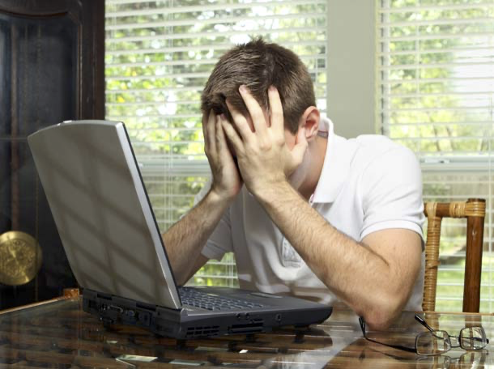

```python
image("frustrated.png")
```

## In machine learning the computer "learns" the algorithm from data.

[figure not shown]

```python
image("machinelearn.jpg")
```

"Machine learning is a field of study that gives computers the ability to learn without being explicitly programmed." --Arthur Samuel (1901-1990).

[figure not shown]

```python
image("arthursamuel.jpg")
```

# The essence of supervised machine learning is *prediction*.

# Simple Linear Regression Key Ideas

- **Key Idea 1:** In SLR, a single feature variable is used to predict a single target variable.
- **Key Idea 2:**: In SLR, the feature and target variables are both continuous.
- **Key Idea 3:** In SLR, the feature and target variables are represented as vectors for the purpose of computation.
- **Key Idea 4:** In SLR, the model is a straight line, also called the regression line and the line of best fit.
- **Key Idea 5:** Each machine learning model is specified by its parameters. SLR has two model parameters: $\beta_0$ and $\beta_1$. $\beta_0$ is the intercept of the regression line and $\beta_1$ is the slope.
- **Key Idea 6:** In SLR, a key metric for evaluating model accuracy is R2 (pronounced "R squared").

# Simple Linear Regression Overview

```python
image("slroverview.png")
```